### Trends in seabird abundance

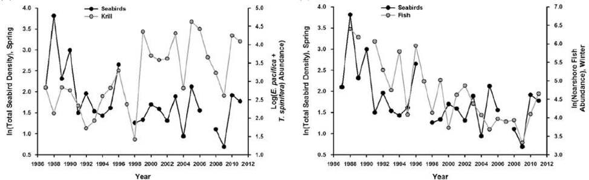

**Figure App.F.13.22.**. A figure showing trends in seabird abundance and the relative abundace of krill and forage fish from 1987-2011.

**Click for Details**

Trends in seabird abundance and the relative abundance of krill and forage fish, based on CalCOFI/CCE LTER program data (1987–2011). Spring and summer seabird density declined by 2 percent per year, mostly in the northern sector of the study region. Krill showed variable trends. Nearshore forage fish, dominated by northern anchovy, and offshore mesopelagic species show declines in relative abundance over this period. Figure: Sydeman et al. 2015

### Seabirds - species richness map

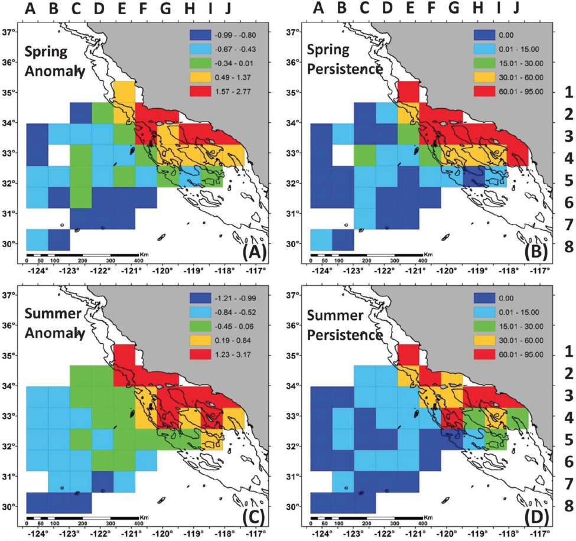

**Figure App.F.15.7.**. A series of maps showing some unexpected trends in seabird species presence (A,C) and persistnce of unepxected presence (B,D) around the Southern California Bight.

**Click for Details**

Seabird species richness spatial anomalies (A,C) and persistence of hotspots (B,D) based on visual survey for seabirds during spring and summer CalCOFI surveys from 1987 to 2012. A spatial anomaly was computed from the grand spatial mean and standard deviation for each block. Cool colors denote blocks below the mean and warm colors denote blocks above. Higher species richness and hotspot persistence (red, yellow) is observed along the coast and around Channel Islands compared to offshore (blue). Seabird species richness calculations based on 68 species/taxa. Figure: Santora and Sydeman 2015

### Seabirds - species richness trends

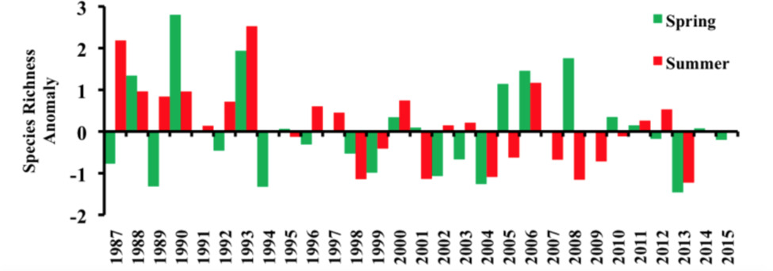

**Figure App.F.15.8.**. A graph showing the change of seabird species presnce in spring (bring) and summer (red) from 1987 - 2015.

**Click for Details**